# Исследование объявлений о продаже квартир

### Изучите, зависит ли цена от площади, числа комнат, удалённости от центра. Изучите зависимость цены от того, на каком этаже расположена квартира: первом, последнем или другом, а также зависимость от даты размещения: дня недели, месяца и года.

Посмотрим на распределение цен в объявлениях.

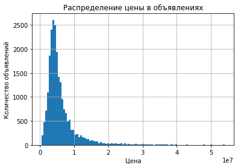

```python
data['last_price'].hist(bins=100, grid=True)
data['last_price'].describe()
plt.title('Распределение цены в объявлениях')
plt.xlabel("Цена")
plt.ylabel("Количество объявлений")
```

```python
print('Описательная статистика по столбцу last_price.')
data['last_price'].describe()
```

```
Описательная статистика по столбцу last_price.
```

```
count    2.305400e+04
mean     6.039537e+06
std      5.060892e+06
min      4.300000e+05
25%      3.450000e+06
50%      4.650000e+06
75%      6.750000e+06
max      5.400000e+07
Name: last_price, dtype: float64
```

Посмотрим на распределение цены от общей площади.

```
Коэффициент Пирсона: 0.779
```

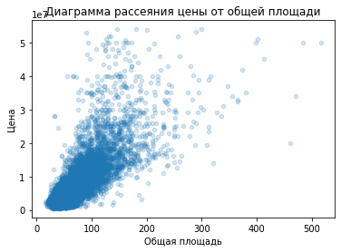

```python
data.plot(x='total_area', y='last_price', kind='scatter', alpha=0.2)
plt.title('Диаграмма рассеяния цены от общей площади')
plt.xlabel("Общая площадь")
plt.ylabel("Цена")
print('Коэффициент Пирсона:', round(data['total_area'].corr(data['last_price']), 3))
```

Посмотрим на распределение цены от площади кухни.

```
Коэффициент Пирсона: 0.604
```

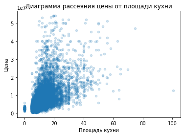

```python
data.plot(x='kitchen_area', y='last_price', kind='scatter', alpha=0.2)
plt.title('Диаграмма рассеяния цены от площади кухни')
plt.xlabel("Площадь кухни")
plt.ylabel("Цена")
print('Коэффициент Пирсона:', round(data['kitchen_area'].corr(data['last_price']), 3))
```

Посмотрим на распределение цены от жилой площади.

```
Коэффициент Пирсона: 0.678
```

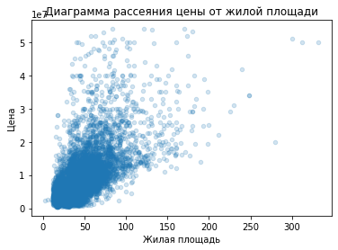

```python
data.plot(x='living_area', y='last_price', kind='scatter', alpha=0.2)
plt.title('Диаграмма рассеяния цены от жилой площади')
plt.xlabel("Жилая площадь")
plt.ylabel("Цена")
print('Коэффициент Пирсона:', round(data['living_area'].corr(data['last_price']), 3))
```

Посмотрим на распределение цены от количества комнат.

```
Коэффициент Пирсона: 0.505
```

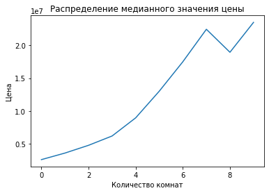

```python
# В данном случае точечная диаграмма неинформативна, построим кривую медианной цены
print('Коэффициент Пирсона:', round(data['rooms'].corr(data['last_price']), 3))
data.groupby('rooms')['last_price'].median().plot()
plt.title('Распределение медианного значения цены')
plt.xlabel('Количество комнат')
plt.ylabel('Цена')
plt.show()
```

При увеличение количества комнат до 7 включительно цена растет. Далее зависимость нарушается, цена больше зависит от площади, чем от количества комнат.

Посмотрим на распределение цены в зависимости от удалённости от центра.

```
Коэффициент Пирсона: -0.329
```

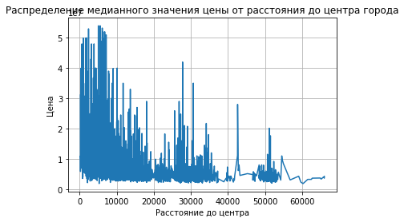

```python
# В данном случае точечная диаграмма не достаточно информативна, построим кривую
print('Коэффициент Пирсона:', round(data['city_centers_nearest'].corr(data['last_price']), 3))
data.groupby('city_centers_nearest')['last_price'].median().plot(grid=True)
plt.title('Распределение медианного значения цены от расстояния до центра города')
plt.xlabel('Расстояние до центра')
plt.ylabel('Цена')
plt.show()
```

В ростом расстояния от центра наблюдается уменьшение цен, но линейной зависимости нет.

Посмотрим на распределение цены в зависимости от этажа.

```
Коэффициент Пирсона: 0.055
```

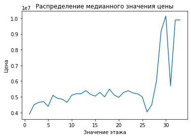

```python
# В данном случае точечная диаграмма неинформативна, построим кривую
print('Коэффициент Пирсона:', round(data['floor'].corr(data['last_price']), 3))
data.groupby('floor')['last_price'].median().plot()
plt.title('Распределение медианного значения цены')
plt.xlabel('Значение этажа')
plt.ylabel('Цена')
plt.show()
```

Посмотрим, зависит ли цена от категории этажа (первого/другой/последнего).

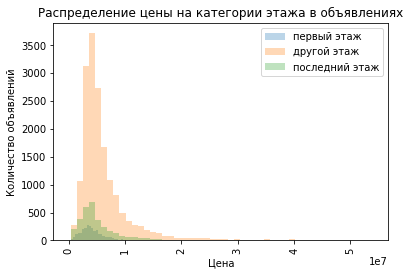

```python
data.query('floor_category == "первый"')['last_price'].plot(alpha = 0.3 , bins = 50, kind='hist', label='первый этаж', range=(0, 20000000))
data.query('floor_category == "другой"')['last_price'].plot.hist(alpha = 0.3, bins = 50, label='другой этаж')
data.query('floor_category == "последний"')['last_price'].plot.hist(alpha = 0.3, bins = 50, label='последний этаж')
plt.title('Распределение цены на категории этажа в объявлениях')
plt.xlabel('Цена')
plt.ylabel('Количество объявлений')
plt.xticks(rotation = 90)
plt.legend()
plt.show()
```

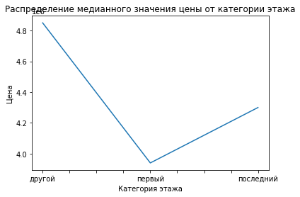

```python
# Посмотрим на медианные значения категорий
data.groupby('floor_category')['last_price'].median().plot()
plt.title('Распределение медианного значения цены от категории этажа')
plt.xlabel('Категория этажа')
plt.ylabel('Цена')
plt.show()
```

Действительно квартиры на последнем этаже стоят дороже, чем на первом, но самые дорогие квартиры находятся на всех этажах кроме первого и последнего.

Посмотрим, зависит ли цена от этажности.

```
Коэффициент Пирсона: 0.036
```

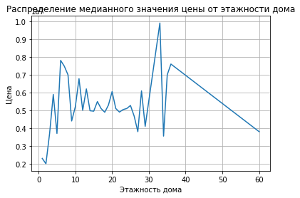

```python
# В данном случае точечная диаграмма неинформативна, построим кривую
print('Коэффициент Пирсона:', round(data['floors_total'].corr(data['last_price']), 3))
data.groupby('floors_total')['last_price'].median().plot(grid=True)
plt.title('Распределение медианного значения цены от этажности дома')
plt.xlabel('Этажность дома')
plt.ylabel('Цена')
plt.show()
```

Посмотрим, зависит ли цена от дня недели размещения объявления.

```
Коэффициент Пирсона: -0.018
```

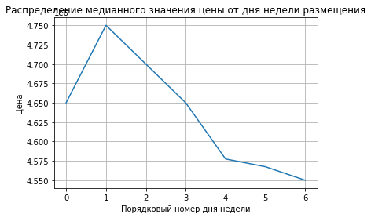

```python
# В данном случае точечная диаграмма неинформативна, построим кривую
print('Коэффициент Пирсона:', round(data['exposition_day_of_week'].corr(data['last_price']), 3))
data.groupby('exposition_day_of_week')['last_price'].median().plot(grid=True)
plt.title('Распределение медианного значения цены от дня недели размещения')
plt.xlabel('Порядковый номер дня недели')
plt.ylabel('Цена')
plt.show()
```

Самая лучший день для продажи - вторник, а самые худшие - пятница, суббота, воскресенье.

Чтобы исключить случайность проверим распределение по годам.

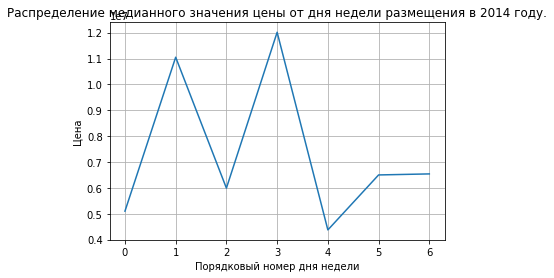

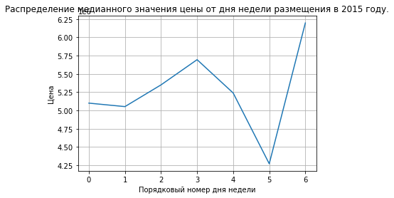

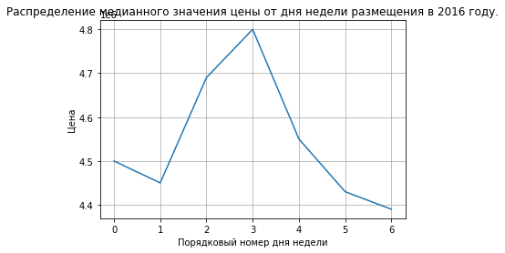

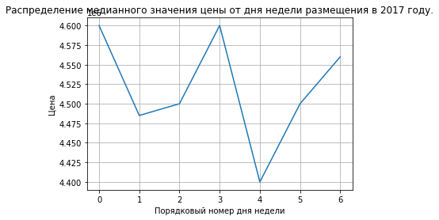

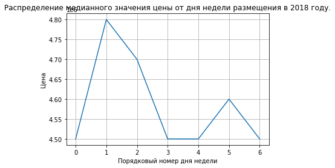

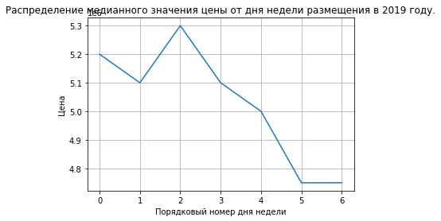

```python
for i in sorted(data['exposition_year'].unique()):
    data.query('exposition_year == @i').groupby('exposition_day_of_week')['last_price'].median().plot(grid=True)
    plt.title(f'Распределение медианного значения цены от дня недели размещения в {i} году.')
    plt.xlabel('Порядковый номер дня недели')
    plt.ylabel('Цена')
    plt.show()
    print()
```

Анализ различных годов показал, что никакой зависимости от дня недели нет.

Посмотрим на распределение цены в зависимости от месяца размещения объявления.

```
Коэффициент Пирсона: 0.005
```

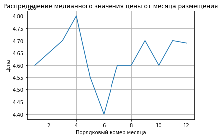

```python
# В данном случае точечная диаграмма неинформативна, построим кривую
print('Коэффициент Пирсона:', round(data['exposition_month'].corr(data['last_price']), 3))
data.groupby('exposition_month')['last_price'].median().plot(grid=True)
plt.title('Распределение медианного значения цены от месяца размещения')
plt.xlabel('Порядковый номер месяца')
plt.ylabel('Цена')
plt.show()
```

Самая лучший месяц для продажи - апрель, а самый худший - июнь.

Чтобы исключить случайность проверим распределение по годам.

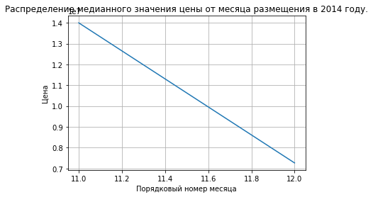

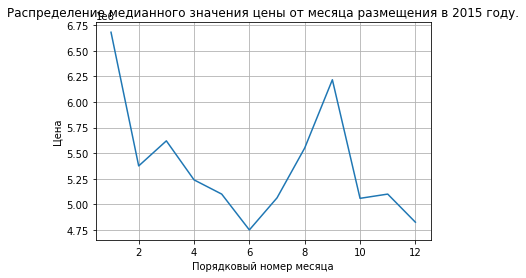

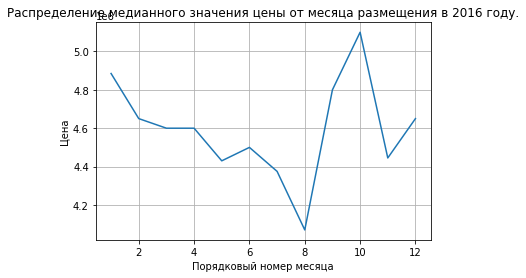

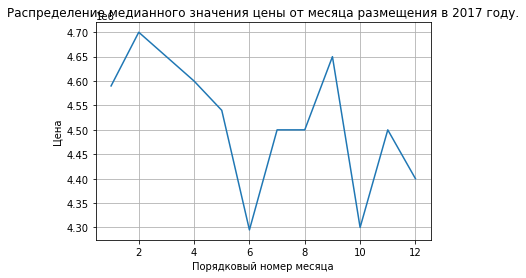

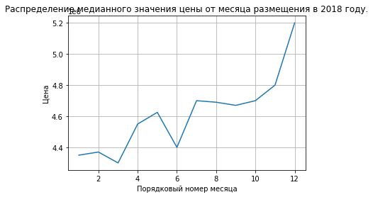

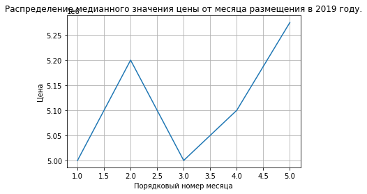

```python
for i in sorted(data['exposition_year'].unique()):
    data.query('exposition_year == @i').groupby('exposition_month')['last_price'].median().plot(grid=True)
    plt.title(f'Распределение медианного значения цены от месяца размещения в {i} году.')
    plt.xlabel('Порядковый номер месяца')
    plt.ylabel('Цена')
    plt.show()
    print()
```

Действительно, июнь - плохой месяц для продаж, что скорее всего связано с сезоном отпусков. С остальными месяцами зависимость не подтвердилась.

Посмотрим на распределение цены в зависимости от года размещения объявления.

```
Коэффициент Пирсона: -0.042
```

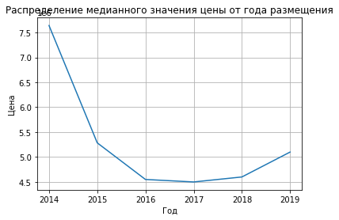

```python
# В данном случае точечная диаграмма неинформативна, построим кривую
print('Коэффициент Пирсона:', round(data['exposition_year'].corr(data['last_price']), 3))
data.groupby('exposition_year')['last_price'].median().plot(grid=True)
plt.title('Распределение медианного значения цены от года размещения')
plt.xlabel('Год')
plt.ylabel('Цена')
plt.show()
```

Самый лучший год для продажи квартиры был 2014, далее видимо на стоимости сказался кризис. После 2018 начался небольшой рост цены.

**Вывод**

После анализа можно сделать следующие выводы:

Больше всего влияния на стоимость оказывают: площадь, количество комнат, удаление от центра, срок публикации (год).

### Выберите 10 населённых пунктов с наибольшим числом объявлений. Посчитайте среднюю цену квадратного метра в этих населённых пунктах. Выделите населённые пункты с самой высокой и низкой стоимостью жилья.

Выведем сводную таблицу из 10 населённых пунктов с наибольшим числом объявлений. Для данных населенных пунктов определим среднюю, минимальную и максимальную стоимость квадратного метра.

```python
data.pivot_table(index='locality_name', values='price_per_meter', aggfunc=['count', 'mean', 'min', 'max']).sort_values(('count','price_per_meter'), ascending=False).round(2).head(10)
```

| locality_name | count price_per_meter | mean price_per_meter | min price_per_meter | max price_per_meter |
| --- | --- | --- | --- | --- |
| Санкт-Петербург | 15314 | 112174.85 | 15345.27 | 848484.85 |
| посёлок Мурино | 525 | 85166.40 | 50000.00 | 130000.00 |
| посёлок Шушары | 426 | 78031.49 | 47700.42 | 147826.09 |
| Всеволожск | 392 | 68577.37 | 31400.00 | 640422.35 |
| Пушкин | 365 | 103186.61 | 59836.07 | 256521.74 |
| Колпино | 337 | 75480.55 | 47957.37 | 125000.00 |
| посёлок Парголово | 318 | 89887.64 | 39205.96 | 138522.43 |
| Гатчина | 297 | 68736.54 | 10507.25 | 146315.79 |
| деревня Кудрово | 291 | 92508.16 | 54160.35 | 142857.14 |
| Выборг | 234 | 58021.28 | 18750.00 | 107473.12 |

Выведем сводную таблицу из 10 населённых пунктов с самой низкой стоимостью жилья.

```python
data.pivot_table(index='locality_name', values='last_price', aggfunc=['median']).sort_values(by=('median', 'last_price'), ascending=True).round(2).head(10)
```

| locality_name | median last_price |
| --- | --- |
| деревня Старополье | 450000.0 |
| деревня Вахнова Кара | 450000.0 |
| деревня Чудской Бор | 500000.0 |
| посёлок Совхозный | 517500.0 |
| посёлок станции Свирь | 575000.0 |
| деревня Выскатка | 585000.0 |
| деревня Ям-Тесово | 625000.0 |
| деревня Коркино | 650000.0 |
| деревня Фалилеево | 650000.0 |
| посёлок Цвылёво | 650000.0 |

Выведем сводную таблицу из 10 населённых пунктов с самой высокой стоимостью жилья.

```python
data.pivot_table(index='locality_name', values='last_price', aggfunc=['median']).sort_values(by=('median', 'last_price'), ascending=False).round(2).head(10)
```

| locality_name | median last_price |
| --- | --- |
| деревня Хязельки | 11000000.0 |
| деревня Бор | 10397600.0 |
| посёлок Александровская | 8725000.0 |
| посёлок Репино | 8083708.0 |
| Санкт-Петербург | 5500000.0 |
| Сестрорецк | 5490000.0 |
| Пушкин | 5200000.0 |
| Зеленогорск | 5000000.0 |
| деревня Глинка | 4750000.0 |
| коттеджный посёлок Счастье | 4650000.0 |

**Вывод**

Самая высокая средняя цена квадратного метра в Санкт-Петербурге. Самая низкая медианная цена на жилье в деревнях Старополье и Вахнова Кара, а самая высокая - в деревне Хязельки.

### По информации о расстоянии до центра Санкт-Петербурга необходимо определеить границу центральной зоны.

```python
# Создадим столбец city_centers_km - расстояние до центра в км
data['city_centers_km'] = round(data['city_centers_nearest'] / 1000)
```

```python
# Посмотрим на результат
data.head()
```

|  | total_images | last_price | total_area | first_day_exposition | rooms | ceiling_height | floors_total | living_area | floor | is_apartment | ... | ponds_nearest | days_exposition | price_per_meter | exposition_day_of_week | exposition_month | exposition_year | floor_category | kitchen_to_total | living_to_total | city_centers_km |
| --- | --- | --- | --- | --- | --- | --- | --- | --- | --- | --- | --- | --- | --- | --- | --- | --- | --- | --- | --- | --- | --- |
| 0 | 20 | 13000000.0 | 108.0 | 2019-03-07 | 3 | 2.700 | 16 | 51.0 | 8 | NaN | ... | 755.0 | 0 | 120370.37 | 3 | 3 | 2019 | другой | 0.231 | 0.472 | 16.0 |
| 1 | 7 | 3350000.0 | 40.4 | 2018-12-04 | 1 | 2.715 | 11 | 18.6 | 1 | NaN | ... | NaN | 81 | 82920.79 | 1 | 12 | 2018 | первый | 0.272 | 0.460 | 19.0 |
| 2 | 10 | 5196000.0 | 56.0 | 2015-08-20 | 2 | 2.555 | 5 | 34.3 | 4 | NaN | ... | 574.0 | 558 | 92785.71 | 3 | 8 | 2015 | другой | 0.148 | 0.612 | 14.0 |
| 3 | 2 | 10000000.0 | 100.0 | 2018-06-19 | 2 | 3.030 | 14 | 32.0 | 13 | NaN | ... | 48.0 | 121 | 100000.00 | 1 | 6 | 2018 | другой | 0.410 | 0.320 | 8.0 |
| 4 | 10 | 2890000.0 | 30.4 | 2018-09-10 | 1 | 2.650 | 12 | 14.4 | 5 | NaN | ... | NaN | 55 | 95065.79 | 0 | 9 | 2018 | другой | 0.299 | 0.474 | NaN |

5 rows × 30 columns

| city_centers_km | last_price |
| --- | --- |
| 0.0 | 2.057746e+07 |
| 1.0 | 1.312392e+07 |
| 2.0 | 1.251293e+07 |
| 3.0 | 1.036633e+07 |
| 4.0 | 1.119909e+07 |
| 5.0 | 1.189814e+07 |
| 6.0 | 1.226303e+07 |
| 7.0 | 1.168026e+07 |
| 8.0 | 9.170974e+06 |
| 9.0 | 7.003213e+06 |
| 10.0 | 6.446835e+06 |
| 11.0 | 6.156740e+06 |
| 12.0 | 5.844508e+06 |
| 13.0 | 6.082358e+06 |
| 14.0 | 5.653303e+06 |
| 15.0 | 5.905512e+06 |
| 16.0 | 5.392699e+06 |
| 17.0 | 5.290045e+06 |
| 18.0 | 5.144900e+06 |
| 19.0 | 5.069572e+06 |
| 20.0 | 5.960256e+06 |
| 21.0 | 5.523612e+06 |
| 22.0 | 5.422567e+06 |
| 23.0 | 4.985376e+06 |
| 24.0 | 3.890687e+06 |
| 25.0 | 4.335000e+06 |
| 26.0 | 4.248470e+06 |
| 27.0 | 8.300000e+06 |
| 28.0 | 5.274125e+06 |
| 29.0 | 4.236667e+06 |

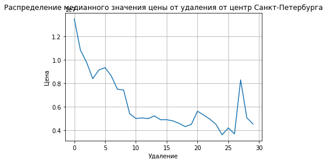

```python
# Определим границу центра
display(data.query('locality_name == "Санкт-Петербург"').pivot_table(index='city_centers_km', values='last_price', aggfunc='mean'))
data.query('locality_name == "Санкт-Петербург"').groupby('city_centers_km')['last_price'].median().plot(grid=True)
plt.title('Распределение медианного значения цены от удаления от центр Санкт-Петербурга')
plt.xlabel('Удаление')
plt.ylabel('Цена')
plt.show()
```

**Вывод**

Будем считать, что центральная зона Санкт-Петербурга заканчивается на 3 км. Пик в районе 5 км можно объяснить наличием элитной видовой недвижимости.

### Выделите сегмент квартир в центре. Проанализируйте эту территорию и изучите следующие параметры: площадь, цена, число комнат, высота потолков. Также выделите факторы, которые влияют на стоимость квартиры (число комнат, этаж, удалённость от центра, дата размещения объявления).

```python
# Для упрощения сохраним выборку с объявлениями в центре Санкт-Петербурга
data_spb_centr = data[(data['locality_name'] == 'Санкт-Петербург') & (data['city_centers_km'] <= 3)]
```

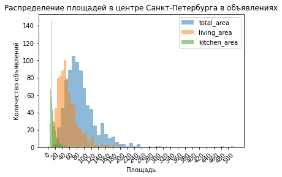

```python
# Площадь
data_spb_centr['total_area'].plot.hist(alpha = 0.5 , bins = 50)
data_spb_centr['living_area'].plot.hist(alpha = 0.5, bins = 50)
data_spb_centr['kitchen_area'].plot.hist(alpha = 0.5, bins = 50)
plt.title('Распределение площадей в центре Санкт-Петербурга в объявлениях')
plt.xlabel("Площадь")
plt.ylabel("Количество объявлений")
plt.xticks(np.arange(0, data_spb_centr['total_area'].max(), 20))
plt.xticks(rotation = 45)
plt.legend()
plt.show()
```

```python
for i in ['kitchen_area', 'living_area', 'total_area']:
    print(f'Описательная статистика по столбцу {i} в центре Санкт-Петербурга.')
    display(data_spb_centr[i].describe())
```

```
Описательная статистика по столбцу kitchen_area в центре Санкт-Петербурга.
```

```
count    825.000000
mean      13.994921
std        7.791468
min        0.000000
25%        9.000000
50%       11.530000
75%       17.000000
max       56.200000
Name: kitchen_area, dtype: float64
```

```
Описательная статистика по столбцу living_area в центре Санкт-Петербурга.
```

```
count    825.000000
mean      57.037539
std       33.005494
min       12.100000
25%       35.700000
50%       49.750000
75%       69.600000
max      332.000000
Name: living_area, dtype: float64
```

```
Описательная статистика по столбцу total_area в центре Санкт-Петербурга.
```

```
count    825.000000
mean      92.704691
std       46.977840
min       16.000000
25%       63.000000
50%       83.000000
75%      110.000000
max      517.000000
Name: total_area, dtype: float64
```

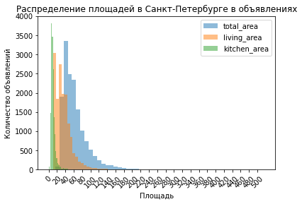

```python
data[data['locality_name'] == 'Санкт-Петербург']['total_area'].plot.hist(alpha = 0.5 , bins = 50)
data[data['locality_name'] == 'Санкт-Петербург']['living_area'].plot.hist(alpha = 0.5, bins = 50)
data[data['locality_name'] == 'Санкт-Петербург']['kitchen_area'].plot.hist(alpha = 0.5, bins = 50)
plt.title('Распределение площадей в Санкт-Петербурге в объявлениях')
plt.xlabel("Площадь")
plt.ylabel("Количество объявлений")
plt.xticks(np.arange(0, data[data['locality_name'] == 'Санкт-Петербург']['total_area'].max(), 20))
plt.xticks(rotation = 45)
plt.legend()
plt.show()
```

```python
for i in ['kitchen_area', 'living_area', 'total_area']:
    print(f'Описательная статистика по столбцу {i} в Санкт-Петербурге.')
    display(data[data['locality_name'] == 'Санкт-Петербург'][i].describe())
```

```
Описательная статистика по столбцу kitchen_area в Санкт-Петербурге.
```

```
count    15314.000000
mean        10.830688
std          5.778970
min          0.000000
25%          7.200000
50%          9.670000
75%         12.165000
max        100.700000
Name: kitchen_area, dtype: float64
```

```
Описательная статистика по столбцу living_area в Санкт-Петербурге.
```

```
count    15314.000000
mean        36.186119
std         21.561753
min          5.000000
25%         19.600000
50%         31.200000
75%         44.000000
max        332.000000
Name: living_area, dtype: float64
```

```
Описательная статистика по столбцу total_area в Санкт-Петербурге.
```

```
count    15314.000000
mean        63.325514
std         33.792734
min         15.500000
25%         42.000000
50%         55.000000
75%         74.000000
max        517.000000
Name: total_area, dtype: float64
```

Графики похожи. Площади квартир в центре города больше, чем по всему городу.

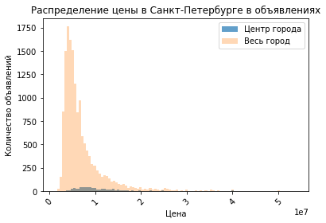

```python
# Цена
data_spb_centr['last_price'].plot.hist(alpha = 0.7 , bins = 100, label='Центр города')
data[data['locality_name'] == 'Санкт-Петербург']['last_price'].plot.hist(alpha = 0.3, bins = 100, label='Весь город')
plt.title('Распределение цены в Санкт-Петербурге в объявлениях')
plt.xlabel("Цена")
plt.ylabel("Количество объявлений")
plt.xticks(np.arange(0, data[data['locality_name'] == 'Санкт-Петербург']['last_price'].max(), 10000000))
plt.xticks(rotation = 45)
plt.legend()
plt.show()
```

```python
print('Описательная статистика по столбцу last_price в центре Санкт-Петербурга.')
display(data_spb_centr['last_price'].describe())
print('Описательная статистика по столбцу last_price для всего Санкт-Петербурга.')
display(data[data['locality_name'] == 'Санкт-Петербург']['last_price'].describe())
```

```
Описательная статистика по столбцу last_price в центре Санкт-Петербурга.
```

```
count    8.250000e+02
mean     1.197936e+07
std      7.869459e+06
min      2.100000e+06
25%      7.200000e+06
50%      9.500000e+06
75%      1.400000e+07
max      5.300000e+07
Name: last_price, dtype: float64
```

```
Описательная статистика по столбцу last_price для всего Санкт-Петербурга.
```

```
count    1.531400e+04
mean     7.300762e+06
std      5.604056e+06
min      1.200000e+06
25%      4.200000e+06
50%      5.500000e+06
75%      8.000000e+06
max      5.400000e+07
Name: last_price, dtype: float64
```

Гистограмма показывает, что в центре объявлений меньше, но стоят они дороже (график смещен правее по цене). В центре цена находится в диапазоне от 2.1 млн до 53 млн, при этом медианное значение 9,5 млн. Во всем городе цена находится в диапазоне от 1.2 млн до 54 млн, при этом медианное значение 5,5 млн.

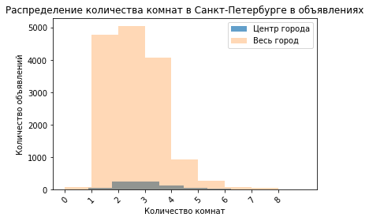

```python
# Число комнат
data_spb_centr['rooms'].plot.hist(alpha = 0.7 , bins = 9, label='Центр города')
data[data['locality_name'] == 'Санкт-Петербург']['rooms'].plot.hist(alpha = 0.3, bins = 9, label='Весь город')
plt.title('Распределение количества комнат в Санкт-Петербурге в объявлениях')
plt.xlabel("Количество комнат")
plt.ylabel("Количество объявлений")
plt.xticks(np.arange(0, data[data['locality_name'] == 'Санкт-Петербург']['rooms'].max(), 1))
plt.xticks(rotation = 45)
plt.legend()
plt.show()
```

```python
print('Описательная статистика по столбцу rooms в центре Санкт-Петербурга.')
display(data_spb_centr['rooms'].describe())
print('Описательная статистика по столбцу rooms в  Санкт-Петербурге.')
data[data['locality_name'] == 'Санкт-Петербург']['rooms'].describe()
```

```
Описательная статистика по столбцу rooms в центре Санкт-Петербурга.
```

```
count    825.000000
mean       3.040000
std        1.349074
min        0.000000
25%        2.000000
50%        3.000000
75%        4.000000
max        8.000000
Name: rooms, dtype: float64
```

```
Описательная статистика по столбцу rooms в  Санкт-Петербурге.
```

```
count    15314.000000
mean         2.160507
std          1.082428
min          0.000000
25%          1.000000
50%          2.000000
75%          3.000000
max          9.000000
Name: rooms, dtype: float64
```

В центре преобладают 3х комнатные квартиры, а по всему городу больше всего 2х комнатных квартир.

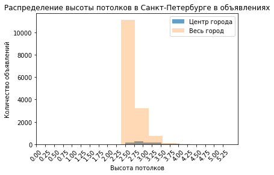

```python
# Высота потолков
data_spb_centr['ceiling_height'].plot.hist(alpha = 0.7 , bins = 9, label='Центр города')
data[data['locality_name'] == 'Санкт-Петербург']['ceiling_height'].plot.hist(alpha = 0.3, bins = 9, label='Весь город')
plt.title('Распределение высоты потолков в Санкт-Петербурге в объявлениях')
plt.xlabel("Высота потолков")
plt.ylabel("Количество объявлений")
plt.xticks(np.arange(0, data[data['locality_name'] == 'Санкт-Петербург']['ceiling_height'].max(), 0.25))
plt.xticks(rotation = 45)
plt.legend()
plt.show()
```

```python
print('Описательная статистика по столбцу ceiling_height в центре Санкт-Петербурга.')
display(data_spb_centr['ceiling_height'].describe())
print('Описательная статистика по столбцу ceiling_height в Санкт-Петербурге.')
data[data['locality_name'] == 'Санкт-Петербург']['ceiling_height'].describe()
```

```
Описательная статистика по столбцу ceiling_height в центре Санкт-Петербурга.
```

```
count    825.000000
mean       3.078733
std        0.371183
min        2.500000
25%        2.820000
50%        3.000000
75%        3.300000
max        4.800000
Name: ceiling_height, dtype: float64
```

```
Описательная статистика по столбцу ceiling_height в Санкт-Петербурге.
```

```
count    15283.000000
mean         2.730213
std          0.246696
min          2.000000
25%          2.550000
50%          2.700000
75%          2.800000
max          5.500000
Name: ceiling_height, dtype: float64
```

В центре высота потолков больше, чем по всему городу.

Проверим факторы, которые влияют на стоимость квартиры: число комнат, этаж, удалённость от центра, дата размещения объявления, площадь.

```
Коэффициент Пирсона для центра: 0.392
Коэффициент Пирсона для всего города: 0.529
```

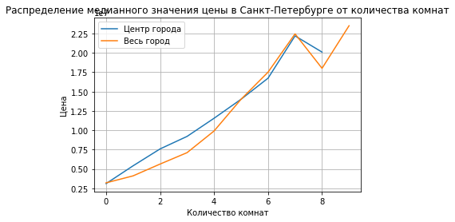

```python
# Количество комнат
# В данном случае точечная диаграмма неинформативна, построим кривую
print('Коэффициент Пирсона для центра:', round(data_spb_centr['rooms'].corr(data['last_price']), 3))
print('Коэффициент Пирсона для всего города:', round(data[data['locality_name'] == 'Санкт-Петербург']['rooms'].corr(data[data['locality_name'] == 'Санкт-Петербург']['last_price']), 3))
data_spb_centr.groupby('rooms')['last_price'].median().plot(grid=True, label='Центр города')
data[data['locality_name'] == 'Санкт-Петербург'].groupby('rooms')['last_price'].median().plot(grid=True, label='Весь город')
plt.title('Распределение медианного значения цены в Санкт-Петербурге от количества комнат')
plt.xlabel('Количество комнат')
plt.ylabel('Цена')
plt.legend()
plt.show()
```

Зависимость цены от количества комнат очень похожи как в центре, так и во всем городе.

```
Коэффициент Пирсона для центра: 0.14
Коэффициент Пирсона для всего города: 0.002
```

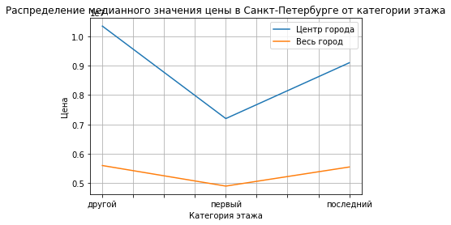

```python
# Этаж
# В данном случае точечная диаграмма неинформативна, построим кривую
print('Коэффициент Пирсона для центра:', round(data_spb_centr['floor'].corr(data['last_price']), 3))
print('Коэффициент Пирсона для всего города:', round(data[data['locality_name'] == 'Санкт-Петербург']['floor'].corr(data[data['locality_name'] == 'Санкт-Петербург']['last_price']),3))
data_spb_centr.groupby('floor_category')['last_price'].median().plot(grid=True, label='Центр города')
data[data['locality_name'] == 'Санкт-Петербург'].groupby('floor_category')['last_price'].median().plot(grid=True, label='Весь город')
plt.title('Распределение медианного значения цены в Санкт-Петербурге от категории этажа')
plt.xlabel('Категория этажа')
plt.ylabel('Цена')
plt.legend()
plt.show()
```

Зависимость цены от категории этажа похожи как в центре, так и во всем городе.

```
Коэффициент Пирсона для центра: -0.19446604277214927
Коэффициент Пирсона для всего города: -0.40188262197805974
```

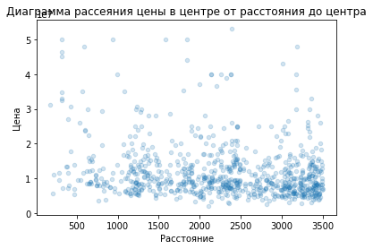

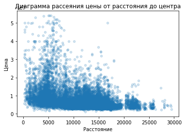

```python
# Удалённость от центра
data_spb_centr.plot(x='city_centers_nearest', y='last_price', kind='scatter', alpha=0.2)
plt.title('Диаграмма рассеяния цены в центре от расстояния до центра')
plt.xlabel("Расстояние")
plt.ylabel("Цена")
print('Коэффициент Пирсона для центра:', data_spb_centr['city_centers_nearest'].corr(data['last_price']))
data[data['locality_name'] == 'Санкт-Петербург'].plot(x='city_centers_nearest', y='last_price', kind='scatter', alpha=0.2)
plt.title('Диаграмма рассеяния цены от расстояния до центра')
plt.xlabel("Расстояние")
plt.ylabel("Цена")
print('Коэффициент Пирсона для всего города:', data[data['locality_name'] == 'Санкт-Петербург']['city_centers_nearest'].corr(data[data['locality_name'] == 'Санкт-Петербург']['last_price']))
```

```
Коэффициент Пирсона для центра: -0.008350642738102812
Коэффициент Пирсона для всего города: 0.0749945301096166
```

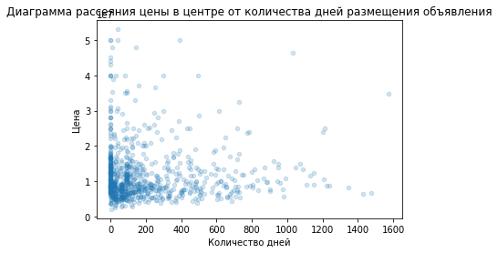

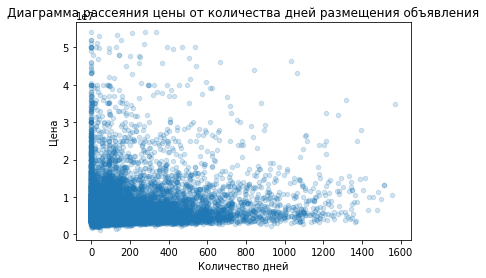

```python
data_spb_centr.plot(x='days_exposition', y='last_price', kind='scatter', alpha=0.2)
plt.title('Диаграмма рассеяния цены в центре от количества дней размещения объявления')
plt.xlabel("Количество дней")
plt.ylabel("Цена")
print('Коэффициент Пирсона для центра:', data_spb_centr['days_exposition'].corr(data['last_price']))
data[data['locality_name'] == 'Санкт-Петербург'].plot(x='days_exposition', y='last_price', kind='scatter', alpha=0.2)
plt.title('Диаграмма рассеяния цены от количества дней размещения объявления')
plt.xlabel("Количество дней")
plt.ylabel("Цена")
print('Коэффициент Пирсона для всего города:', data[data['locality_name'] == 'Санкт-Петербург']['days_exposition'].corr(data[data['locality_name'] == 'Санкт-Петербург']['last_price']))
```

```
Коэффициент Пирсона для центра: 0.6270029502297136
Коэффициент Пирсона для всего города: 0.7945151736676674
```

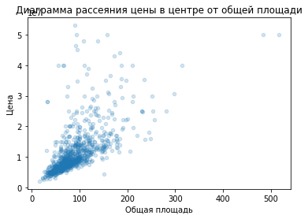

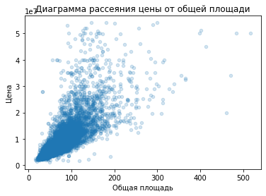

```python
data_spb_centr.plot(x='total_area', y='last_price', kind='scatter', alpha=0.2)
plt.title('Диаграмма рассеяния цены в центре от общей площади')
plt.xlabel("Общая площадь")
plt.ylabel("Цена")
print('Коэффициент Пирсона для центра:', data_spb_centr['total_area'].corr(data['last_price']))
data[data['locality_name'] == 'Санкт-Петербург'].plot(x='total_area', y='last_price', kind='scatter', alpha=0.2)
plt.title('Диаграмма рассеяния цены от общей площади')
plt.xlabel("Общая площадь")
plt.ylabel("Цена")
print('Коэффициент Пирсона для всего города:', data[data['locality_name'] == 'Санкт-Петербург']['total_area'].corr(data[data['locality_name'] == 'Санкт-Петербург']['last_price']))
```

**Вывод**

## Общий вывод

На основании выполненной работы можно сделать выводы, что на рыночную стоимость недвижимости влияют ее следующие параметры:

- площадь объекта,
- количество комнат,
- удаление от центра города (деление города на части, наименование населенного пункта),
- срок размещения объявления (год размещения),
- этаж, на котором находится объект (категория этажа).

Влияние данных параметров на стоимость нелинейное. Рыночная стоимость объектов недвижимости определяется совокупностью данных параметров. Вот краткое сравнение основных параметров для центра Санкт-петербурга, всего Санкт-петербурга и всей выборки.

### Площадь объекта

```
Коэффициент Пирсона для центра Санкт-Петербурга: 0.627
Медианное значение общей площади в центре Санкт-Петербурга 83.0
Медианное значение стоимости в центре Санкт-Петербурга 9500000.0
```

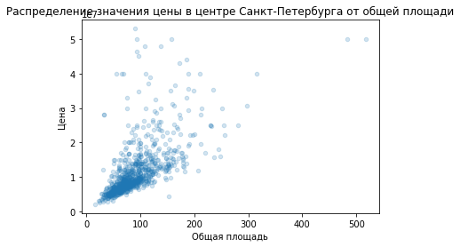

```
Коэффициент Пирсона для всего Санкт-Петербурга: 0.795
Медианное значение общей площади во всем Санкт-Петербурге 55.0
Медианное значение стоимости во всем Санкт-Петербурге 5500000.0
```

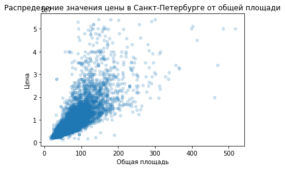

```
Коэффициент Пирсона для всей выборки: 0.779
Медианное значение общей площади для всей выборки 52.0
Медианное значение стоимости для всей выборки 4650000.0
```

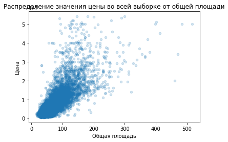

```python
print('Коэффициент Пирсона для центра Санкт-Петербурга:', round(data_spb_centr['total_area'].corr(data['last_price']), 3))
print('Медианное значение общей площади в центре Санкт-Петербурга', data_spb_centr['total_area'].median())
print('Медианное значение стоимости в центре Санкт-Петербурга', data_spb_centr['last_price'].median())
data_spb_centr.plot(x='total_area', y='last_price', kind='scatter', alpha=0.2)
plt.title('Распределение значения цены в центре Санкт-Петербурга от общей площади')
plt.xlabel('Общая площадь')
plt.ylabel('Цена')
plt.show()
print('Коэффициент Пирсона для всего Санкт-Петербурга:', round(data[data['locality_name'] == 'Санкт-Петербург']['total_area'].corr(data[data['locality_name'] == 'Санкт-Петербург']['last_price']), 3))
print('Медианное значение общей площади во всем Санкт-Петербурге', data[data['locality_name'] == 'Санкт-Петербург']['total_area'].median())
print('Медианное значение стоимости во всем Санкт-Петербурге', data[data['locality_name'] == 'Санкт-Петербург']['last_price'].median())
data[data['locality_name'] == 'Санкт-Петербург'].plot(x='total_area', y='last_price', kind='scatter', alpha=0.2)
plt.title('Распределение значения цены в Санкт-Петербурге от общей площади')
plt.xlabel('Общая площадь')
plt.ylabel('Цена')
plt.show()
print('Коэффициент Пирсона для всей выборки:', round(data['total_area'].corr(data['last_price']), 3))
print('Медианное значение общей площади для всей выборки', data['total_area'].median())
print('Медианное значение стоимости для всей выборки', data['last_price'].median())
data.plot(x='total_area', y='last_price', kind='scatter', alpha=0.2)
plt.title('Распределение значения цены во всей выборке от общей площади')
plt.xlabel('Общая площадь')
plt.ylabel('Цена')
plt.show()
```

С увеличением площади увеличивается и стоимость объекта недвижимости (ниже представлены сравнительные значения параметров для разных выборок).

| Наименование выборки | Коэффициент корреляции | Медианная общая площадь, м. | Медианная цена, млн. |
| --- | --- | --- | --- |
| Центр Санкт-Петербурга | 0.627 | 83 | 9.5 |
| Весь Санкт-Петербург | 0.795 | 55 | 5.5 |
| Вся выборка | 0.779 | 52 | 4.65 |

### Число комнат

```
Коэффициент Пирсона для центра Санкт-Петербурга: 0.392
Медианное значение числа комнат в центре Санкт-Петербурга 3.0
Медианное значение стоимости в центре Санкт-Петербурга 9500000.0

Коэффициент Пирсона для всего Санкт-Петербурга: 0.529
Медианное значение числа комнат во всем Санкт-Петербурге 2.0
Медианное значение стоимости во всем Санкт-Петербурге 5500000.0

Коэффициент Пирсона для всей выборки: 0.505
Медианное значение числа комнат во всей выборке 2.0
Медианное значение стоимости во всей выборке 4650000.0
```

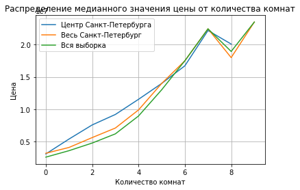

```python
print('Коэффициент Пирсона для центра Санкт-Петербурга:', round(data_spb_centr['rooms'].corr(data_spb_centr['last_price']), 3))
print('Медианное значение числа комнат в центре Санкт-Петербурга', data_spb_centr['rooms'].median())
print('Медианное значение стоимости в центре Санкт-Петербурга', data_spb_centr['last_price'].median())
print()
print('Коэффициент Пирсона для всего Санкт-Петербурга:', round(data[data['locality_name'] == 'Санкт-Петербург']['rooms'].corr(data[data['locality_name'] == 'Санкт-Петербург']['last_price']), 3))
print('Медианное значение числа комнат во всем Санкт-Петербурге', data[data['locality_name'] == 'Санкт-Петербург']['rooms'].median())
print('Медианное значение стоимости во всем Санкт-Петербурге', data[data['locality_name'] == 'Санкт-Петербург']['last_price'].median())
print()
print('Коэффициент Пирсона для всей выборки:', round(data['rooms'].corr(data['last_price']), 3))
print('Медианное значение числа комнат во всей выборке', data['rooms'].median())
print('Медианное значение стоимости во всей выборке', data['last_price'].median())
data_spb_centr.groupby('rooms')['last_price'].median().plot(grid=True, label='Центр Санкт-Петербурга')
data[data['locality_name'] == 'Санкт-Петербург'].groupby('rooms')['last_price'].median().plot(grid=True, label='Весь Санкт-Петербург')
data.groupby('rooms')['last_price'].median().plot(grid=True, label='Вся выборка')
plt.title('Распределение медианного значения цены от количества комнат')
plt.xlabel('Количество комнат')
plt.ylabel('Цена')
plt.legend()
plt.show()
```

С увеличением числа комнат до 7 включительно наблюдается рост стоимости (ниже представлены сравнительные значения параметров для разных выборок).

| Наименование выборки | Коэффициент корреляции | Медианное количество комнат, м. | Медианная цена, млн. |
| --- | --- | --- | --- |
| Центр Санкт-Петербурга | 0.392 | 3 | 9.5 |
| Весь Санкт-Петербург | 0.529 | 2 | 5.5 |
| Вся выборка | 0.505 | 2 | 4.65 |

### Удаление от центра города

```
Коэффициент Пирсона для центра Санкт-Петербурга: -0.209
Медианное значение удаления от центра города в центре Санкт-Петербурга 2.0
Медианное значение стоимости в центре Санкт-Петербурга 9500000.0

Коэффициент Пирсона для всего Санкт-Петербурга: -0.402
Медианное значение удаления от центра города для всего Санкт-Петербурга 12.0
Медианное значение стоимости для всего Санкт-Петербурга 5500000.0

Коэффициент Пирсона для всей выборки: -0.329
Медианное значение удаления от центра города для всей выборки 13.0
Медианное значение стоимости для всей выборки 4650000.0
```

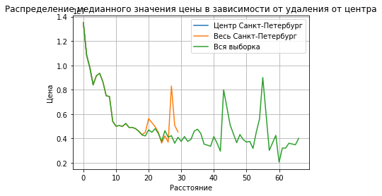

```python
print('Коэффициент Пирсона для центра Санкт-Петербурга:', round(data_spb_centr['city_centers_km'].corr(data_spb_centr['last_price']), 3))
print('Медианное значение удаления от центра города в центре Санкт-Петербурга', data_spb_centr['city_centers_km'].median())
print('Медианное значение стоимости в центре Санкт-Петербурга', data_spb_centr['last_price'].median())
print()
print('Коэффициент Пирсона для всего Санкт-Петербурга:', round(data[data['locality_name'] == 'Санкт-Петербург']['city_centers_km'].corr(data[data['locality_name'] == 'Санкт-Петербург']['last_price']), 3))
print('Медианное значение удаления от центра города для всего Санкт-Петербурга', data[data['locality_name'] == 'Санкт-Петербург']['city_centers_km'].median())
print('Медианное значение стоимости для всего Санкт-Петербурга', data[data['locality_name'] == 'Санкт-Петербург']['last_price'].median())
print()
print('Коэффициент Пирсона для всей выборки:', round(data['city_centers_km'].corr(data['last_price']), 3))
print('Медианное значение удаления от центра города для всей выборки', data['city_centers_km'].median())
print('Медианное значение стоимости для всей выборки', data['last_price'].median())
data_spb_centr.groupby('city_centers_km')['last_price'].median().plot(grid=True, label='Центр Санкт-Петербург')
data[data['locality_name'] == 'Санкт-Петербург'].groupby('city_centers_km')['last_price'].median().plot(grid=True, label='Весь Санкт-Петербург')
data.groupby('city_centers_km')['last_price'].median().plot(grid=True, label='Вся выборка')
plt.title('Распределение медианного значения цены в зависимости от удаления от центра')
plt.xlabel('Расстояние')
plt.ylabel('Цена')
plt.legend()
plt.show()
```

| Наименование выборки | Коэффициент корреляции | Медианное значение удаления от центра, км. | Медианная цена, млн. |
| --- | --- | --- | --- |
| Центр Санкт-Петербурга | -0.209 | 2 | 9.5 |
| Весь Санкт-Петербург | -0.402 | 12 | 5.5 |
| Вся выборка | -0.329 | 13 | 4.65 |

Как видно из графиков и таблицы, удаление от центра города оказывает влияние на стоимость недвижимости, особенно в таком крупном городе, как Санкт-Петербург. Отчетливо видно, что для центральной цасти города влияние расстояния намного ниже, чем для всего города в целом.

### Cрок размещения объявления (days_exposition)

```
Коэффициент Пирсона для центра Санкт-Петербурга: -0.008
Медианное значение срока размещения объявлений в центре Санкт-Петербурга 90.0
Медианное значение стоимости в центре Санкт-Петербурга 9500000.0
```

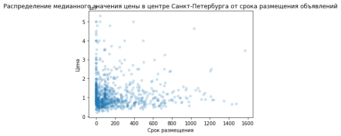

```python
print('Коэффициент Пирсона для центра Санкт-Петербурга:', round(data_spb_centr['days_exposition'].corr(data_spb_centr['last_price']), 3))
print('Медианное значение срока размещения объявлений в центре Санкт-Петербурга', data_spb_centr['days_exposition'].median())
print('Медианное значение стоимости в центре Санкт-Петербурга', data_spb_centr['last_price'].median())
data_spb_centr.plot(x='days_exposition', y='last_price', kind='scatter', alpha=0.2)
plt.title('Распределение медианного значения цены в центре Санкт-Петербурга от срока размещения объявлений')
plt.xlabel('Cрок размещения')
plt.ylabel('Цена')
plt.show()
```

```
Коэффициент Пирсона для всего Санкт-Петербурга: 0.075
Медианное значение срока размещения объявлений для всего Санкт-Петербурга 74.0
Медианное значение стоимости во всем Санкт-Петербурге 5500000.0
```

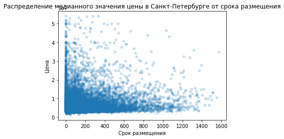

```python
print('Коэффициент Пирсона для всего Санкт-Петербурга:', round(data[data['locality_name'] == 'Санкт-Петербург']['days_exposition'].corr(data[data['locality_name'] == 'Санкт-Петербург']['last_price']), 3))
print('Медианное значение срока размещения объявлений для всего Санкт-Петербурга', data[data['locality_name'] == 'Санкт-Петербург']['days_exposition'].median())
print('Медианное значение стоимости во всем Санкт-Петербурге', data[data['locality_name'] == 'Санкт-Петербург']['last_price'].median())
data[data['locality_name'] == 'Санкт-Петербург'].plot(x='days_exposition', y='last_price', kind='scatter', alpha=0.2)
plt.title('Распределение медианного значения цены в Санкт-Петербурге от срока размещения')
plt.xlabel('Cрок размещения')
plt.ylabel('Цена')
plt.show()
```

```
Коэффициент Пирсона для всей выборки: 0.065
Медианное значение срока размещения объявлений для всей выборки 73.0
Медианное значение стоимости для всей выборки 4650000.0
```

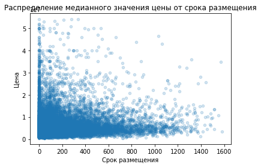

```python
print('Коэффициент Пирсона для всей выборки:', round(data['days_exposition'].corr(data['last_price']), 3))
print('Медианное значение срока размещения объявлений для всей выборки', data['days_exposition'].median())
print('Медианное значение стоимости для всей выборки', data['last_price'].median())
data.plot(x='days_exposition', y='last_price', kind='scatter', alpha=0.2)
plt.title('Распределение медианного значения цены от срока размещения')
plt.xlabel('Cрок размещения')
plt.ylabel('Цена')
plt.show()
```

Квартиры во всей выборке продаются примерно одинаково независимо от срока размещения. Со временем наблюдается незначительное снижение цены, что говорит о том, что продавцам приходится скидывать цену, чтобы продать квартиру.

#### Год размещения объявления

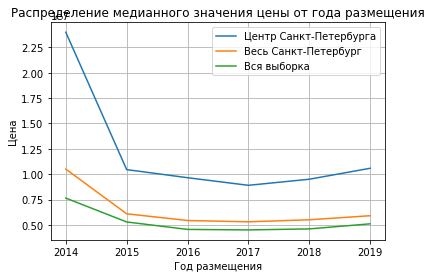

```python
data_spb_centr.groupby('exposition_year')['last_price'].median().plot(grid=True, label='Центр Санкт-Петербурга')
data[data['locality_name'] == 'Санкт-Петербург'].groupby('exposition_year')['last_price'].median().plot(grid=True, label='Весь Санкт-Петербург')
data.groupby('exposition_year')['last_price'].median().plot(grid=True, label='Вся выборка')
plt.title('Распределение медианного значения цены от года размещения')
plt.xlabel('Год размещения')
plt.ylabel('Цена')
plt.legend()
plt.show()
```

Как видно из графиков лучшим годом для продажи недвижимости был 2014, а худшим - 2017.

### Этаж

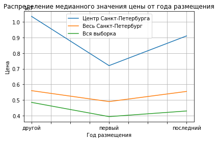

```python
data_spb_centr.groupby('floor_category')['last_price'].median().plot(grid=True, label='Центр Санкт-Петербурга')
data[data['locality_name'] == 'Санкт-Петербург'].groupby('floor_category')['last_price'].median().plot(grid=True, label='Весь Санкт-Петербург')
data.groupby('floor_category')['last_price'].median().plot(grid=True, label='Вся выборка')
plt.title('Распределение медианного значения цены от года размещения')
plt.xlabel('Год размещения')
plt.ylabel('Цена')
plt.legend()
plt.show()
```

Лучше всего продаются квартиры между первым и последним этажами, а хуже всего на первом этаже.